# Статистический анализ данных (задание 1)

Копин Борис

**Цель**: Исследование свойств одномерных статистических критериев на модельных данных

**Описание**: Необходимо провести исследование одного или нескольких классических критериев проверки статистических гипотез. Интерес представляет поведение достигаемого уровня значимости (p-value) как функции размера выборок и параметров распределения. В соответствии с индивидуальными параметрами задания необходимо указанным способом сгенерировать одну или несколько выборок из заданного распределения, выполнить проверку гипотезы при помощи соответствующего критерия, а затем многократно повторить эту процедуру для различных значений параметров.

**Результат**: Необходимо построить требуемые в задании графики, среди которых могут быть следующие: - график зависимости достигаемого уровня значимости от значений параметров при однократном проведении эксперимента; - график зависимости достигаемого уровня значимости одного или двух критериев от значений параметров, усреднённого по большому количеству повторений эксперимента (например, по 1000 повторений); - график с эмпирическими оценками мощности одного или двух критериев для разных значений параметров.

В качестве оценки мощности принимается доля отвержений нулевой гипотезы среди всех проверок. То есть, если эксперимент повторялся $k$ раз для каждого набора значений параметров, и в $m$ из $k$ случаев гипотеза была отвергнута на некотором фиксированном уровне значимости $\alpha$ (примем $\alpha=0.05$), оценкой мощности будет отношение $\frac{m}{k}$.

**Условие задачи**:

Ниже под обозначением $X^{n}, X \sim p\cdot F_{1} + (1 - p)\cdot F_{2}$ понимается выборка объёма $n$ из смеси распределений $F_{1}$ и $F_{2}$ с весами $p$ и $1-p$ соответственно (при генерации каждой выборки используется случайный датчик — если его значение не превосходит {p}, то добавляем в выборку элемент, взятый из $F_{1}$, иначе — элемент, взятый из $F_{2}$).

Требуется исследовать поведение указанного критерия в условиях нарушения лежащих в его основе предположений. Оценить мощность и достигаемый уровень значимости критерия при различных значениях параметров, сделать выводы об устойчивости.

Критерий Фишера для проверки равенства дисперсий, нарушение предположения о нормальности.

$$X_{1}^{n_{1}}, X \sim p_{1} \cdot \mathbb{N}(0, \sigma_{1}^{2}) + (1 - p_{1}) \cdot F_{1}$$
$$X_{2}^{n_{2}}, X \sim p_{2} \cdot \mathbb{N}(0, \sigma_{2}^{2}) + (1 - p_{2}) \cdot F_{2}$$
$$H_{0}: \mathbb{D}X_{1} = \mathbb{D}X_{2}$$
$$H_{1}: \mathbb{D}X_{1} \neq \mathbb{D}X_{2}$$

$F_{1} = F_{2} = U\left[-3, 3\right]$ — непрерывное равномерное распределение;

$$\sigma_{1}=1$$
$$\sigma_{2}=0.5\,:\,0.01\,:\,2$$
$$p_{1}=p_{2} = 0\,:\,0.01\,:\,1$$
$$n_{1}=n_{2}=50$$

**Генерации выборок**

```r
generateX1 <- function(n1, sigma1, p1) {
  F1 <- runif(n1, min = -3, max = 3)
  X1.weight <- runif(n1)

  X1.Norm.ind.matr <- t(vapply(p1, function(p) X1.weight <= p, FUN.VALUE = logical(n1)))
  X1.F1.ind.mart <- !X1.Norm.ind.matr

  X1.F1 <- F1*X1.F1.ind.mart

  X1.Norm <- rnorm(n1, mean = 0, sd = sigma1)
  X1.matr <- X1.Norm*X1.Norm.ind.matr + X1.F1

  X1 <- split(X1.matr, 1:length(p1))

  return(X1)
}

generateX2 <- function(n2, sigma2, p2, weights) {
  F2 <- runif(n2, min = -3, max = 3)
  X2.weight <- runif(n2)

  X2.Norm.ind.matr <- t(vapply(p2, function(p) X2.weight <= p, FUN.VALUE = numeric(n2)))
  X2.F2.ind.mart <- !X2.Norm.ind.matr

  X2.F2 <- F2*X2.F2.ind.mart

  X2.norm.matr <- matrix(rnorm(n2*length(sigma2), mean = 0, sd = sigma2), nrow=length(sigma2))
  X2.norm.list <- split(X2.norm.matr, 1:length(sigma2))

  mixX2Func <- function(X2.sigma.norm) split(X2.Norm.ind.matr*X2.sigma.norm + X2.F2, 1:length(p2))

  X2 <- unlist(lapply(X2.norm.list, mixX2Func), recursive=FALSE)

  return(X2)
}
```

**Подсчет p-value и мощности для однократного эксперимента**

```r
pvpow <- function(cl, n1, n2, p1, p2, sigma1, sigma2) {
  N <- length(sigma2)
  M <- length(p1)

  X1 <- generateX1(n1, sigma1, p1)
  X2 <- generateX2(n2, sigma2, p2)

  X1.X2 <- cbind(X1, X2)

  PV_L <- parApply(cl, X1.X2, 1, function(pair) var.test(pair[[1]], pair[[2]])$p.value)

  PV_M <- matrix(PV_L, nrow = N,  byrow=TRUE)
  PW_M <- PV_M < 0.05

  return(list(PV_M, PW_M))
}
```

**Отрисовка графика**

```r
drawExp <- function(m, x, y, title) {
  N <- length(x)
  M <- length(y)

  grid    <- expand.grid(x=x, y=y)
  x.grid <- matrix(grid$x, nrow=N, ncol=M)
  y.grid <- matrix(grid$y, nrow=N, ncol=M)

  image.plot(y.grid, x.grid, m,
             col = colorRampPalette(c("blue", "cyan", "yellow", "red"))(1024),
             main=title, xlab=expression("p"), ylab=expression("sigma_{2}"))
}
```

**Эксперимент**

```r
library(parallel)

experiment <- function(n1, n2, p1, p2, sigma1, sigma2, iterations = 1, cl) {
  N <- length(sigma2)
  M <- length(p1)

  PV_M  <- rep(0, N * M)
  PW_M  <- rep(0, N * M)

  for(i in 1:iterations) {
    ans <- pvpow(cl, n1, n2, p1, p2, sigma1, sigma2)
    PV_M <- PV_M + ans[[1]]
    PW_M <- PW_M + ans[[2]]
  }

  PV_M <- PV_M/iterations
  PW_M <- PW_M/iterations

  return(list(PV_M, PW_M))
}
```

### Параметры задачи

```r
sigma1 = 1
sigma2 = seq(from = 0.5, to = 2, by = 0.01)
p1 = p2 = seq(from = 0, to = 1, by = 0.01)
n1 = n2 = 50

cl <- makeCluster(detectCores())
```

### Однократный эксперимент

```r
result <- experiment(n1, n2, p1, p2, sigma1, sigma2, 1, cl)

PV_M <- result[[1]]
PW_M <- result[[2]]
```

#### График зависимости достигаемого уровня значимости от значений $\sigma_{2}$ и $p1=p2=p$ при однократном проведении эксперимента.

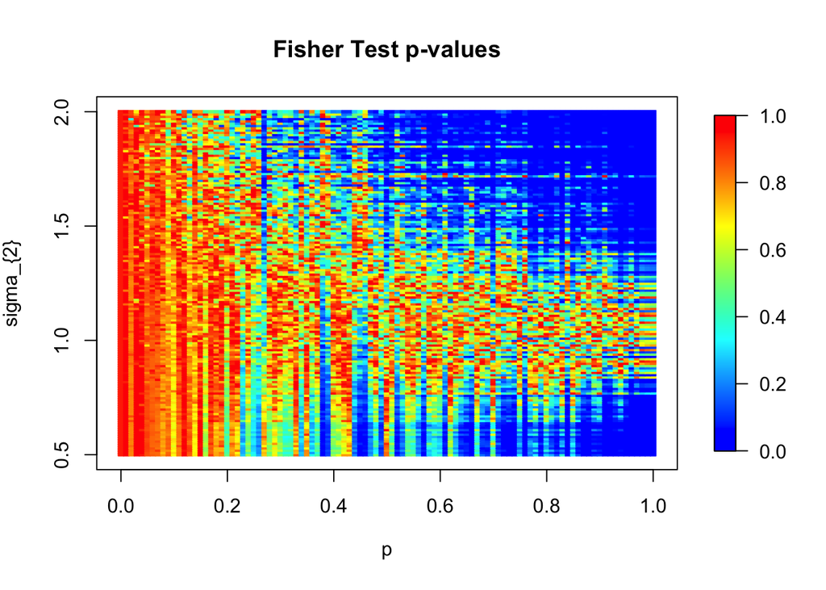

```r
drawExp(PV_M, sigma2, p1, "Fisher Test p-values")
```

### Многократный эксперимент

```r
knitr::opts_chunk$set(message = FALSE)

result <- experiment(n1, n2, p1, p2, sigma1, sigma2, 1000, cl)

PV_M <- result[[1]]
PW_M <- result[[2]]
```

#### График зависимости достигаемого уровня значимости критерия Фишера от значений параметров, усреднённого по большому количеству повторений эксперимента.

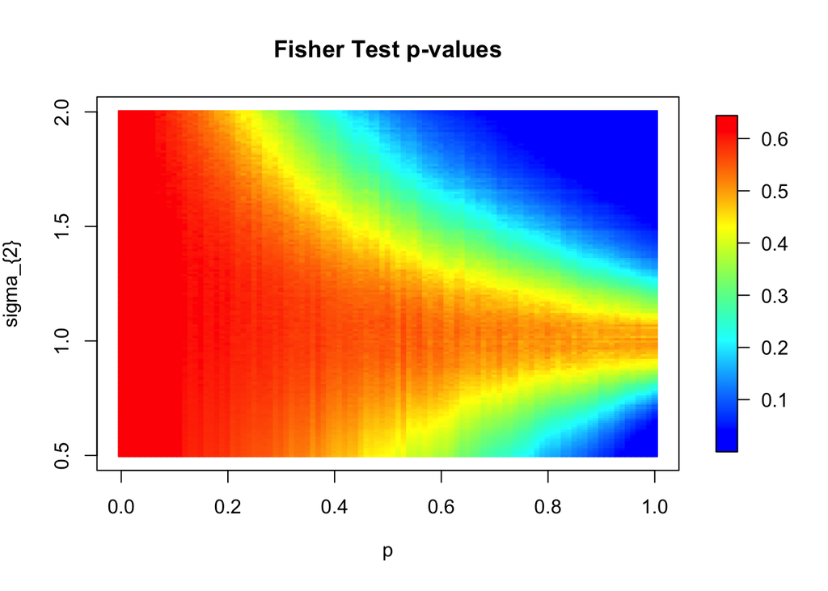

```r
drawExp(PV_M, sigma2, p1, "Fisher Test p-values")
```

#### График с эмпирической оценкой мощности критерия Фишера.

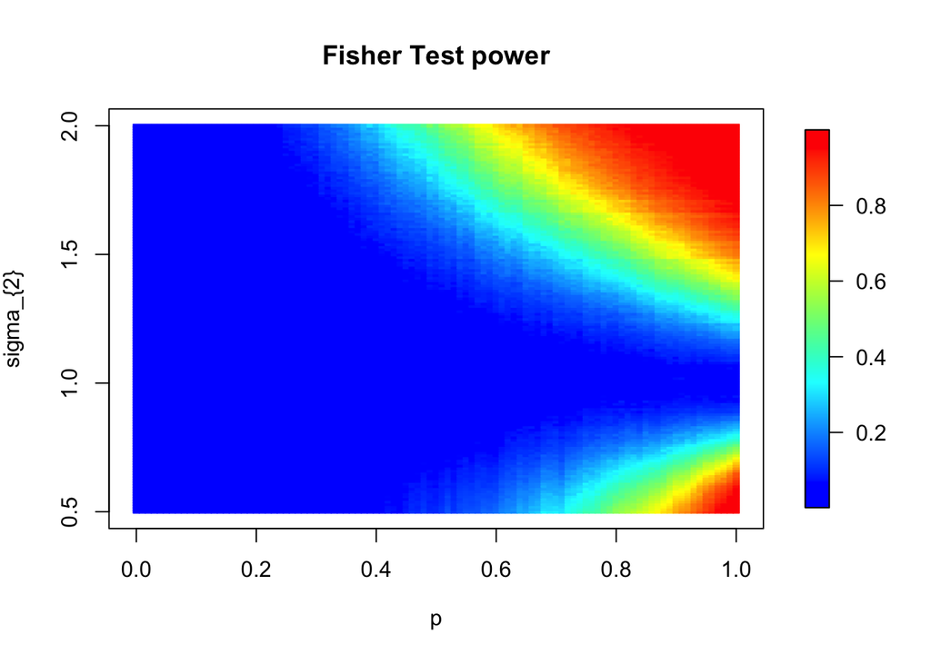

```r
drawExp(PW_M, sigma2, p1, "Fisher Test power")
```

#### Выводы.

Видно, что критерий Фишера устойчив на двух отрезках параметра $p_{1}=p_{2}=p$. На первом отрезке [0, ~0.3] преобладает доля элементов выборок из равномерного распределения. Хотя предположение о нормальности выборок нарушено, критерий на этом отрезке устойчив. Логично, ведь в этом случае в независимости от выбранного параметра sigma2, дисперсии двух выборок равны, т.к. они из одного и того же равномерного распределения. На втором отрезке [~0.8, 1] преобладает доля элементов выборок из нормального распределения. На этом отрезке предположение о нормальности выборок выполнены с небольшим шумом, незначительные отклонения $\sigma_{2}$ от $1$ не дают значимых изменений $p-value$, что логично, т.к. он распределен равномерно на $[0,1]$ при справедливости нулевой гипотезы. А при большой разнице в дисперсиях шум не мешает уверенно отклонять нулевую гипотезу.

На отрезке [~0.3, ~0.8] критерий неустойчив. В данном случае видно, что несоблюдение предположения о нормальности выборок мешает уверенно отклонять нулевую гипотезу при больших различиях в дисперсиях, что говорит о неустойчивости критерия. За исключением случая, когда обе выборки из одного и того же равномерного распределения.